# `Thera Bank Loaner`

## `Data Description:`

The dataset contains data on 5000 customers. The data include customer demographic information (age, income, etc.), the customer's relationship with the bank (mortgage, securities account, etc.), and the customer response to the last personal loan campaign (Personal Loan). Among these 5000 customers, only 480 (= 9.6%) accepted the personal loan that was offered to them in the earlier campaign.

## `Objective:`

The classification goal is to predict the likelihood of a liability customer buying personal loans.

## `Attributes Information:`

- ID: Customer ID
- Age: Customer's age in completed years
- Experience: #years of professional experience
- Income: Annual income of the customer ($000)
- ZIP Code: Home Address ZIP code
- Family: Family size of the customer
- CCAvg: Avg spending on credit cards per month ($000)
- Education: Education Level 1: Undergrad; 2: Graduate; 3: Advanced/Professional
- Mortgage: Value of house mortgage if any ($000)
- Personal Loan: Did this customer accept the personal loan offered in the last campaign?
- Securities Account: Does the customer have a securities account with the bank?
- CD Account: Does the customer have a certificate of deposit (CD) account with the bank?
- Online: Does the customer use internet banking facilities?
- Credit card: Does the customer use a credit card issued by the bank?

## Import Libraries and Load Dataset

```python
import warnings
warnings.filterwarnings('ignore')
```

```python
import pandas as pd
from sklearn.linear_model import LogisticRegression

import matplotlib.pyplot as plt
%matplotlib inline

import seaborn as sns

from sklearn.model_selection import train_test_split

import numpy as np
from scipy import stats

# calculate accuracy measures and confusion matrix
from sklearn import metrics
```

## Part 1

- Importing the datasets and libraries
- Checking datatype, statistical summary, shape, null values or incorrect imputation

```python
df = pd.read_csv('Bank_Personal_Loan_Modelling.csv')
df.head()
```

|  | ID | Age | Experience | Income | ZIP Code | Family | CCAvg | Education | Mortgage | Personal Loan | Securities Account | CD Account | Online | CreditCard |
| --- | --- | --- | --- | --- | --- | --- | --- | --- | --- | --- | --- | --- | --- | --- |
| 0 | 1 | 25 | 1 | 49 | 91107 | 4 | 1.6 | 1 | 0 | 0 | 1 | 0 | 0 | 0 |
| 1 | 2 | 45 | 19 | 34 | 90089 | 3 | 1.5 | 1 | 0 | 0 | 1 | 0 | 0 | 0 |
| 2 | 3 | 39 | 15 | 11 | 94720 | 1 | 1.0 | 1 | 0 | 0 | 0 | 0 | 0 | 0 |
| 3 | 4 | 35 | 9 | 100 | 94112 | 1 | 2.7 | 2 | 0 | 0 | 0 | 0 | 0 | 0 |
| 4 | 5 | 35 | 8 | 45 | 91330 | 4 | 1.0 | 2 | 0 | 0 | 0 | 0 | 0 | 1 |

```python
df.shape
```

```
(5000, 14)
```

```python
df.info()
```

```
<class 'pandas.core.frame.DataFrame'>
RangeIndex: 5000 entries, 0 to 4999
Data columns (total 14 columns):
ID                    5000 non-null int64
Age                   5000 non-null int64
Experience            5000 non-null int64
Income                5000 non-null int64
ZIP Code              5000 non-null int64
Family                5000 non-null int64
CCAvg                 5000 non-null float64
Education             5000 non-null int64
Mortgage              5000 non-null int64
Personal Loan         5000 non-null int64
Securities Account    5000 non-null int64
CD Account            5000 non-null int64
Online                5000 non-null int64
CreditCard            5000 non-null int64
dtypes: float64(1), int64(13)
memory usage: 547.0 KB
```

```python
#Data describe
df.describe().T
```

|  | count | mean | std | min | 25% | 50% | 75% | max |
| --- | --- | --- | --- | --- | --- | --- | --- | --- |
| ID | 5000.0 | 2500.500000 | 1443.520003 | 1.0 | 1250.75 | 2500.5 | 3750.25 | 5000.0 |
| Age | 5000.0 | 45.338400 | 11.463166 | 23.0 | 35.00 | 45.0 | 55.00 | 67.0 |
| Experience | 5000.0 | 20.104600 | 11.467954 | -3.0 | 10.00 | 20.0 | 30.00 | 43.0 |
| Income | 5000.0 | 73.774200 | 46.033729 | 8.0 | 39.00 | 64.0 | 98.00 | 224.0 |
| ZIP Code | 5000.0 | 93152.503000 | 2121.852197 | 9307.0 | 91911.00 | 93437.0 | 94608.00 | 96651.0 |
| Family | 5000.0 | 2.396400 | 1.147663 | 1.0 | 1.00 | 2.0 | 3.00 | 4.0 |
| CCAvg | 5000.0 | 1.937938 | 1.747659 | 0.0 | 0.70 | 1.5 | 2.50 | 10.0 |
| Education | 5000.0 | 1.881000 | 0.839869 | 1.0 | 1.00 | 2.0 | 3.00 | 3.0 |
| Mortgage | 5000.0 | 56.498800 | 101.713802 | 0.0 | 0.00 | 0.0 | 101.00 | 635.0 |
| Personal Loan | 5000.0 | 0.096000 | 0.294621 | 0.0 | 0.00 | 0.0 | 0.00 | 1.0 |
| Securities Account | 5000.0 | 0.104400 | 0.305809 | 0.0 | 0.00 | 0.0 | 0.00 | 1.0 |
| CD Account | 5000.0 | 0.060400 | 0.238250 | 0.0 | 0.00 | 0.0 | 0.00 | 1.0 |
| Online | 5000.0 | 0.596800 | 0.490589 | 0.0 | 0.00 | 1.0 | 1.00 | 1.0 |
| CreditCard | 5000.0 | 0.294000 | 0.455637 | 0.0 | 0.00 | 0.0 | 1.00 | 1.0 |

```python
df.isna().sum()
```

```
ID                    0
Age                   0
Experience            0
Income                0
ZIP Code              0
Family                0
CCAvg                 0
Education             0
Mortgage              0
Personal Loan         0
Securities Account    0
CD Account            0
Online                0
CreditCard            0
dtype: int64
```

```python
df.isnull().sum()
```

```
ID                    0
Age                   0
Experience            0
Income                0
ZIP Code              0
Family                0
CCAvg                 0
Education             0
Mortgage              0
Personal Loan         0
Securities Account    0
CD Account            0
Online                0
CreditCard            0
dtype: int64
```

```python
len(df[(df['Experience']<0)])
```

```
52
```

```python
df['Experience']=df['Experience'].abs()
```

```python
len(df[(df['Experience']<0)])
```

```
0
```

```python
df.describe().T
```

|  | count | mean | std | min | 25% | 50% | 75% | max |
| --- | --- | --- | --- | --- | --- | --- | --- | --- |
| ID | 5000.0 | 2500.500000 | 1443.520003 | 1.0 | 1250.75 | 2500.5 | 3750.25 | 5000.0 |
| Age | 5000.0 | 45.338400 | 11.463166 | 23.0 | 35.00 | 45.0 | 55.00 | 67.0 |
| Experience | 5000.0 | 20.134600 | 11.415189 | 0.0 | 10.00 | 20.0 | 30.00 | 43.0 |
| Income | 5000.0 | 73.774200 | 46.033729 | 8.0 | 39.00 | 64.0 | 98.00 | 224.0 |
| ZIP Code | 5000.0 | 93152.503000 | 2121.852197 | 9307.0 | 91911.00 | 93437.0 | 94608.00 | 96651.0 |
| Family | 5000.0 | 2.396400 | 1.147663 | 1.0 | 1.00 | 2.0 | 3.00 | 4.0 |
| CCAvg | 5000.0 | 1.937938 | 1.747659 | 0.0 | 0.70 | 1.5 | 2.50 | 10.0 |
| Education | 5000.0 | 1.881000 | 0.839869 | 1.0 | 1.00 | 2.0 | 3.00 | 3.0 |
| Mortgage | 5000.0 | 56.498800 | 101.713802 | 0.0 | 0.00 | 0.0 | 101.00 | 635.0 |
| Personal Loan | 5000.0 | 0.096000 | 0.294621 | 0.0 | 0.00 | 0.0 | 0.00 | 1.0 |
| Securities Account | 5000.0 | 0.104400 | 0.305809 | 0.0 | 0.00 | 0.0 | 0.00 | 1.0 |
| CD Account | 5000.0 | 0.060400 | 0.238250 | 0.0 | 0.00 | 0.0 | 0.00 | 1.0 |
| Online | 5000.0 | 0.596800 | 0.490589 | 0.0 | 0.00 | 1.0 | 1.00 | 1.0 |
| CreditCard | 5000.0 | 0.294000 | 0.455637 | 0.0 | 0.00 | 0.0 | 1.00 | 1.0 |

**Insights:**

- Different Dtype (data-type) shown here:
  - float64
  - int64
  - Data length is 5000 rows
    - All columns have the same length
    - No NaN values were found
    - No null values were found
    - Negative values on 'Experience' column were replaced by positive values

# Part 2

**EDA: Data distribution in each attribute and target variable**

- Number of unique in each column
- Number of people with zero mortgage
- Number of people with zero credit card spending per month
- Value counts of all categorical columns
- Univariate and Bivariate
- Data preparation for modeling: Log transformation and Standard Scaling, replacing outliers

```python
# Number of unique values in a column
df.nunique()
```

```
ID                    5000
Age                     45
Experience              44
Income                 162
ZIP Code               467
Family                   4
CCAvg                  108
Education                3
Mortgage               347
Personal Loan            2
Securities Account       2
CD Account               2
Online                   2
CreditCard               2
dtype: int64
```

**Insights:**

```python
# dropping this column
df.drop('ID', axis =1, inplace=True )
```

```python
#Convert X & Y variable to a categorical variable wherever relevant
for i in['ZIP Code', 'Family', 'Education', 'Personal Loan', 'Securities Account', 'CD Account', 'Online', 'CreditCard']:
    df[i] = df[i].astype('category')
```

```python
df.dtypes
```

```
Age                      int64
Experience               int64
Income                   int64
ZIP Code              category
Family                category
CCAvg                  float64
Education             category
Mortgage                 int64
Personal Loan         category
Securities Account    category
CD Account            category
Online                category
CreditCard            category
dtype: object
```

```python
#checking spread for 'Family' category
df['Family'].value_counts(normalize=True)*100
```

```
1    29.44
2    25.92
4    24.44
3    20.20
Name: Family, dtype: float64
```

```python
#checking spread for 'Education' category
df['Education'].value_counts(normalize=True)*100
```

```
1    41.92
3    30.02
2    28.06
Name: Education, dtype: float64
```

```python
#checking spread for 'Personal Loan' category
df['Personal Loan'].value_counts(normalize=True)
```

```
0    0.904
1    0.096
Name: Personal Loan, dtype: float64
```

#### Number of people with zero mortgage

```python
# number of people with zero mortgage
df.loc[df['Mortgage']==0].shape[0]
```

```
3462
```

```python
#checking spread for 'Personal Loan' category for group with zero Mortgage
df.loc[df['Mortgage']==0]['Personal Loan'].value_counts(normalize=True)
```

```
0    0.909879
1    0.090121
Name: Personal Loan, dtype: float64
```

```python
#checking spread for 'Personal Loan' category for group with non-zero Mortgage
df.loc[df['Mortgage']!=0]['Personal Loan'].value_counts(normalize=True)
```

```
0    0.890767
1    0.109233
Name: Personal Loan, dtype: float64
```

#### Number of people with zero credit card spending per month

```python
# Number of people with zero credit card spending per month
df.loc[df['CCAvg']==0].shape[0]
```

```
106
```

#### Value counts of all category type columns

```python
# Value counts of all categorical columns
for i in list(df.columns[df.dtypes=='category']):
    print(df[i].value_counts(normalize=True)*100)
    print()
```

```
94720    3.38
94305    2.54
95616    2.32
90095    1.42
93106    1.14
         ...
92694    0.02
94965    0.02
94970    0.02
91024    0.02
9307     0.02
Name: ZIP Code, Length: 467, dtype: float64

1    29.44
2    25.92
4    24.44
3    20.20
Name: Family, dtype: float64

1    41.92
3    30.02
2    28.06
Name: Education, dtype: float64

0    90.4
1     9.6
Name: Personal Loan, dtype: float64

0    89.56
1    10.44
Name: Securities Account, dtype: float64

0    93.96
1     6.04
Name: CD Account, dtype: float64

1    59.68
0    40.32
Name: Online, dtype: float64

0    70.6
1    29.4
Name: CreditCard, dtype: float64
```

## Univariate Analysis

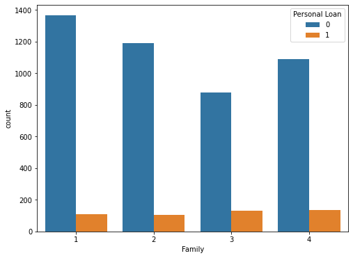

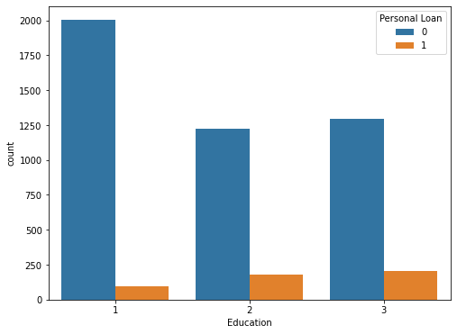

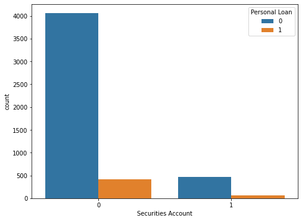

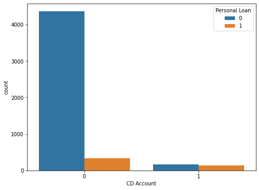

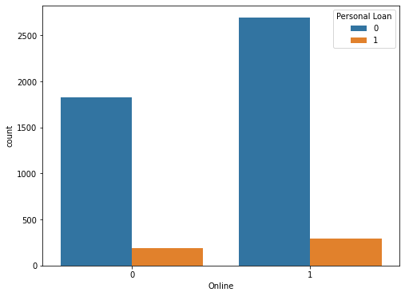

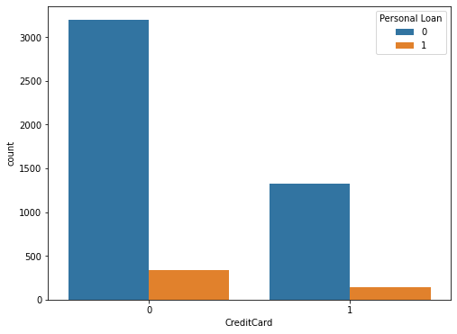

```python
#countplot for categorical columns with two groups of Personal Loan (0 = no; 1 = yes)
for i in ['Family', 'Education', 'Securities Account', 'CD Account', 'Online', 'CreditCard']:
    plt.figure(figsize=(8,6))
    sns.countplot(x = i, data=df, hue='Personal Loan')
#    plt.xticks(rotation=0)
    plt.show()
```

**Insights from countplots:**

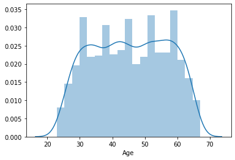

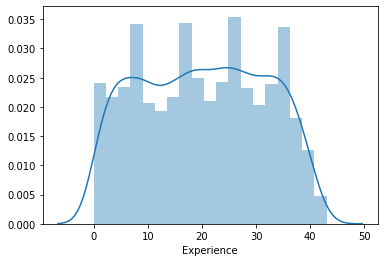

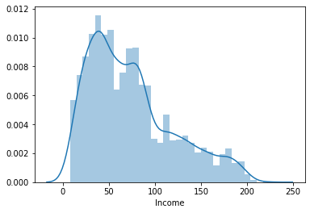

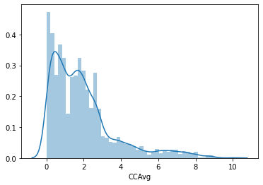

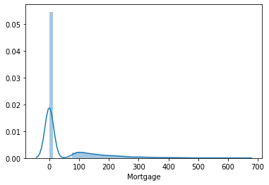

```python
# distplot for continous columns
for i in ['Age','Experience','Income', 'CCAvg', 'Mortgage']:
    sns.distplot(df[i])
    plt.show()
```

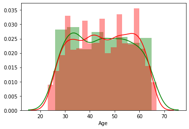

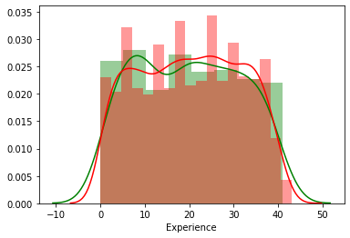

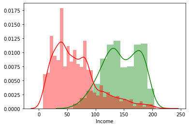

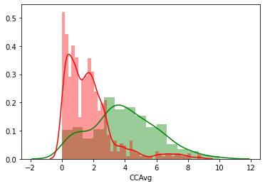

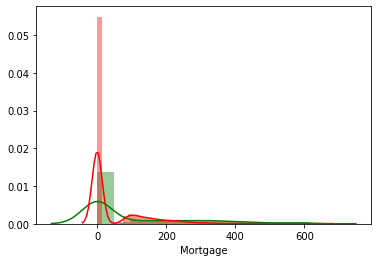

```python
# distplot for continous columns for group that took the loan vs. group that did not
yes_loan=df.loc[df['Personal Loan']==1]
no_loan=df.loc[df['Personal Loan']==0]

for i in ['Age','Experience','Income', 'CCAvg', 'Mortgage']:
    sns.distplot(yes_loan[i], color='green')
    sns.distplot(no_loan[i], color='red')
    plt.show()
```

**Insights from distribution plots:**

- `Age and Experience seem not to have much impact on taking a loan`
- `People with higher income above 100 tend more to take a loan`
- `People with higher monthly credit card spendings above 3 tend more to take a loan`
- `Mortgage seem not to have much impact on taking a loan`

## Bivariate Analysis

```python
df.groupby(['Personal Loan']).mean()
```

| Personal Loan | Age | Experience | Income | CCAvg | Mortgage |
| --- | --- | --- | --- | --- | --- |
| 0 | 45.367257 | 20.165487 | 66.237389 | 1.729009 | 51.789381 |
| 1 | 45.066667 | 19.843750 | 144.745833 | 3.905354 | 100.845833 |

```python
df.groupby(['Personal Loan']).median()
```

| Personal Loan | Age | Experience | Income | CCAvg | Mortgage |
| --- | --- | --- | --- | --- | --- |
| 0 | 45.0 | 20.0 | 59.0 | 1.4 | 0.0 |
| 1 | 45.0 | 20.0 | 142.5 | 3.8 | 0.0 |

```python
df.mode()
```

|  | Age | Experience | Income | ZIP Code | Family | CCAvg | Education | Mortgage | Personal Loan | Securities Account | CD Account | Online | CreditCard |
| --- | --- | --- | --- | --- | --- | --- | --- | --- | --- | --- | --- | --- | --- |
| 0 | 35 | 32 | 44 | 94720 | 1 | 0.3 | 1 | 0 | 0 | 0 | 0 | 1 | 0 |

**Insights from grouping continious variables by Personal Loan:**

- `Age and Experience seem not to have much impact on taking a loan`
- `People with higher income tend more to take a loan`
- `People with higher monthly credit card spendings above 3 tend more to take a loan`
- `Mean of Mortgage can be missleading because Median is the same for yes-loan or no-loan`

```python
pd.crosstab(df['Family'],df['Personal Loan'],normalize='columns')
```

| Personal Loan Family | 0 | 1 |
| --- | --- | --- |
| 1 | 0.301991 | 0.222917 |
| 2 | 0.263274 | 0.220833 |
| 3 | 0.194027 | 0.277083 |
| 4 | 0.240708 | 0.279167 |

```python
pd.crosstab(df['Education'],df['Personal Loan'],normalize='columns')
```

| Personal Loan Education | 0 | 1 |
| --- | --- | --- |
| 1 | 0.443142 | 0.193750 |
| 2 | 0.270133 | 0.379167 |
| 3 | 0.286726 | 0.427083 |

```python
pd.crosstab(df['Securities Account'],df['Personal Loan'],normalize='columns')
```

| Personal Loan Securities Account | 0 | 1 |
| --- | --- | --- |
| 0 | 0.897788 | 0.875 |
| 1 | 0.102212 | 0.125 |

```python
pd.crosstab(df['CD Account'],df['Personal Loan'],normalize='columns')
```

| Personal Loan CD Account | 0 | 1 |
| --- | --- | --- |
| 0 | 0.964159 | 0.708333 |
| 1 | 0.035841 | 0.291667 |

```python
pd.crosstab(df['Online'],df['Personal Loan'],normalize='columns')
```

| Personal Loan Online | 0 | 1 |
| --- | --- | --- |
| 0 | 0.404204 | 0.39375 |
| 1 | 0.595796 | 0.60625 |

```python
pd.crosstab(df['CreditCard'],df['Personal Loan'],normalize='columns')
```

| Personal Loan CreditCard | 0 | 1 |
| --- | --- | --- |
| 0 | 0.706416 | 0.702083 |
| 1 | 0.293584 | 0.297917 |

**Insights from crosstabs:**

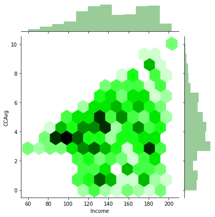

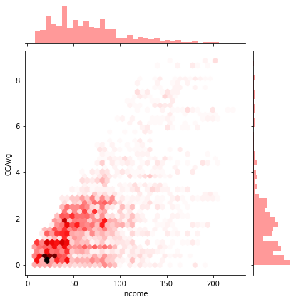

```python
sns.jointplot(yes_loan['Income'], yes_loan['CCAvg'], kind = "hex",color='green')
sns.jointplot(no_loan['Income'], no_loan['CCAvg'], kind = "hex",color='red')
plt.show()
```

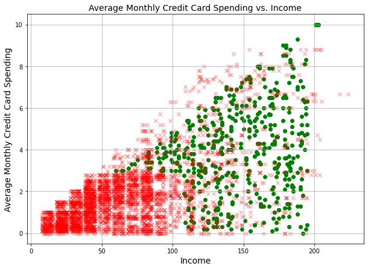

```python
plt.figure(figsize=(10,7))
plt.scatter(yes_loan['Income'], yes_loan['CCAvg'], color='green')
plt.scatter(no_loan['Income'], no_loan['CCAvg'], color='red', marker='x', alpha=0.3)
plt.title('Average Monthly Credit Card Spending vs. Income', fontsize=14)
plt.xlabel('Income', fontsize=14)
plt.ylabel('Average Monthly Credit Card Spending', fontsize=14)
plt.grid(True)
plt.show()
```

```python
for i in ['Family', 'Education']:
    print(yes_loan[i].value_counts(normalize=True)*100)
```

```
4    27.916667
3    27.708333
1    22.291667
2    22.083333
Name: Family, dtype: float64
3    42.708333
2    37.916667
1    19.375000
Name: Education, dtype: float64
```

```python
for i in ['Family', 'Education']:
    print(no_loan[i].value_counts(normalize=True)*100)
```

```
1    30.199115
2    26.327434
4    24.070796
3    19.402655
Name: Family, dtype: float64
1    44.314159
3    28.672566
2    27.013274
Name: Education, dtype: float64
```

```python
#Value counts of all categorical columns grouped by 'Personal Loan'

for i in ['Family', 'Education', 'Securities Account', 'CD Account', 'Online', 'CreditCard']:
    print(df.groupby([i])['Personal Loan'].value_counts(normalize=True)*100)
```

```
Family  Personal Loan
1       0                92.730978
        1                 7.269022
2       0                91.820988
        1                 8.179012
3       0                86.831683
        1                13.168317
4       0                89.034370
        1                10.965630
Name: Personal Loan, dtype: float64
Education  Personal Loan
1          0                95.562977
           1                 4.437023
2          0                87.027798
           1                12.972202
```

[output cut: 27 more lines]

**Summary Insights**

### People observed to take a loan:

- Income > 100, the higher the better the chance
- CCAvg > 2, optimum in a range 3 - 5
- Larger families of 3 and 4
- People with higher education of 2 and 3
  - Group of people with Income below 100 and CCAvg below 3 are not taking a loan (must be the minimum income restriction for loan application)

## Data preparation for modeling: Log transformation and Standard Scaling, replacing outliers

### Log Transformation

```python
from sklearn.preprocessing import FunctionTransformer

log_transformer = FunctionTransformer(np.log1p)

log_transformer
```

```
FunctionTransformer(accept_sparse=False, check_inverse=True,
                    func=<ufunc 'log1p'>, inv_kw_args=None, inverse_func=None,
                    kw_args=None, pass_y='deprecated', validate=None)
```

```python
#separate dataset with continious numerical values
num_df = df[['Age', 'Experience', 'CCAvg', 'Income','Mortgage', 'Personal Loan']]
```

```python
#sns.pairplot?
```

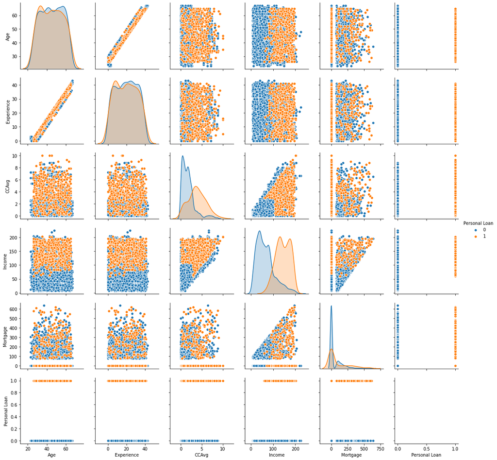

```python
sns.pairplot(num_df, hue='Personal Loan', diag_kind='kde')
plt.show()
```

```python
#drop  the 'Experience' column as highly dependand on the 'Age'
num_df.drop(['Experience'], axis=1, inplace=True)
num_df.keys()
```

```
Index(['Age', 'CCAvg', 'Income', 'Mortgage', 'Personal Loan'], dtype='object')
```

```python
features = [col for col in num_df.columns if col != 'Personal Loan']
```

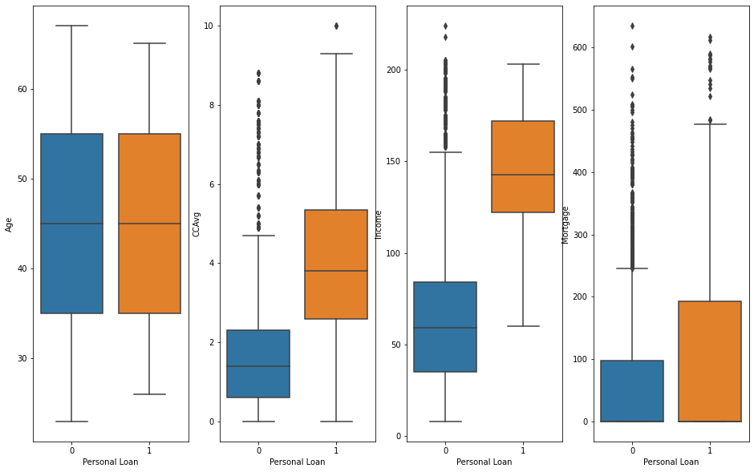

```python
# Boxplots to understand differences in distributions among the attributes and visualize outliers
fig, axs = plt.subplots(ncols = len(features), figsize = (16, 10))

for idx, field in enumerate(features):
    sns.boxplot(x = 'Personal Loan',
                y = field,
                data = num_df,
                ax = axs[idx])
```

```python
# Log transformation for columns mith multiple outliers: Income, Mortgage and CCAvg
for i in ['Income', 'Mortgage', 'CCAvg']:
    num_df[i+'_transformed']=log_transformer.fit_transform(num_df[[i]])

num_df.head()
```

|  | Age | CCAvg | Income | Mortgage | Personal Loan | Income_transformed | Mortgage_transformed | CCAvg_transformed |
| --- | --- | --- | --- | --- | --- | --- | --- | --- |
| 0 | 25 | 1.6 | 49 | 0 | 0 | 3.912023 | 0.0 | 0.955511 |
| 1 | 45 | 1.5 | 34 | 0 | 0 | 3.555348 | 0.0 | 0.916291 |
| 2 | 39 | 1.0 | 11 | 0 | 0 | 2.484907 | 0.0 | 0.693147 |
| 3 | 35 | 2.7 | 100 | 0 | 0 | 4.615121 | 0.0 | 1.308333 |
| 4 | 35 | 1.0 | 45 | 0 | 0 | 3.828641 | 0.0 | 0.693147 |

```python
num_df.drop(['Income', 'Mortgage', 'CCAvg'], axis=1, inplace=True)
```

```python
features = [col for col in num_df.columns if col != 'Personal Loan']
```

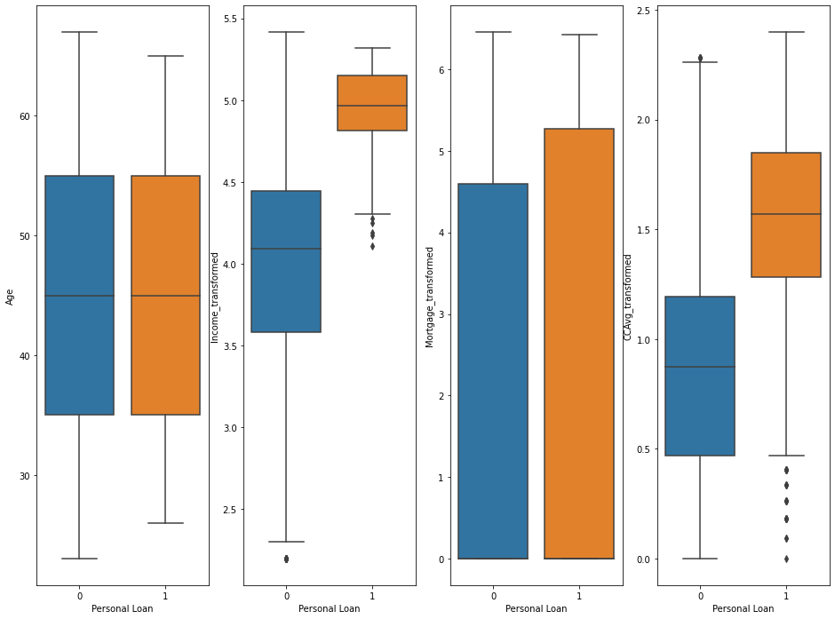

```python
# Boxplots to visualize outliers after the transformation
fig, axs = plt.subplots(ncols = len(features), figsize = (16, 12))

for idx, field in enumerate(features):
    sns.boxplot(x = 'Personal Loan',
                y = field,
                data = num_df,
                ax = axs[idx])
```

**Insights:**

- `Number of outliers were significantly decreased using the Log transformation`

### Standard Scaling

```python
from sklearn.preprocessing import StandardScaler

scale = StandardScaler()

scale
```

```
StandardScaler(copy=True, with_mean=True, with_std=True)
```

```python
num_df2=num_df.drop('Personal Loan', axis=1)
for (columnName, columnData) in num_df2.iteritems():
    num_df2[columnName+'_scaled']=scale.fit_transform(num_df2[[columnName]])

num_df2.head()
```

|  | Age | Income_transformed | Mortgage_transformed | CCAvg_transformed | Age_scaled | Income_transformed_scaled | Mortgage_transformed_scaled | CCAvg_transformed_scaled |
| --- | --- | --- | --- | --- | --- | --- | --- | --- |
| 0 | 25 | 3.912023 | 0.0 | 0.955511 | -1.774417 | -0.286700 | -0.662238 | 0.049051 |
| 1 | 45 | 3.555348 | 0.0 | 0.916291 | -0.029524 | -0.811294 | -0.662238 | -0.024503 |
| 2 | 39 | 2.484907 | 0.0 | 0.693147 | -0.552992 | -2.385689 | -0.662238 | -0.442985 |
| 3 | 35 | 4.615121 | 0.0 | 1.308333 | -0.901970 | 0.747409 | -0.662238 | 0.710731 |
| 4 | 35 | 3.828641 | 0.0 | 0.693147 | -0.901970 | -0.409337 | -0.662238 | -0.442985 |

```python
num_df2.dtypes
```

```
Age                              int64
Income_transformed             float64
Mortgage_transformed           float64
CCAvg_transformed              float64
Age_scaled                     float64
Income_transformed_scaled      float64
Mortgage_transformed_scaled    float64
CCAvg_transformed_scaled       float64
dtype: object
```

```python
#drop the original columns, leaving the scaled only
num_df2.drop(['Age', 'Income_transformed', 'Mortgage_transformed', 'CCAvg_transformed'], axis=1, inplace=True)
num_df2['Personal Loan']=df['Personal Loan']
```

```python
features = [col for col in num_df2.columns if col != 'Personal Loan']
```

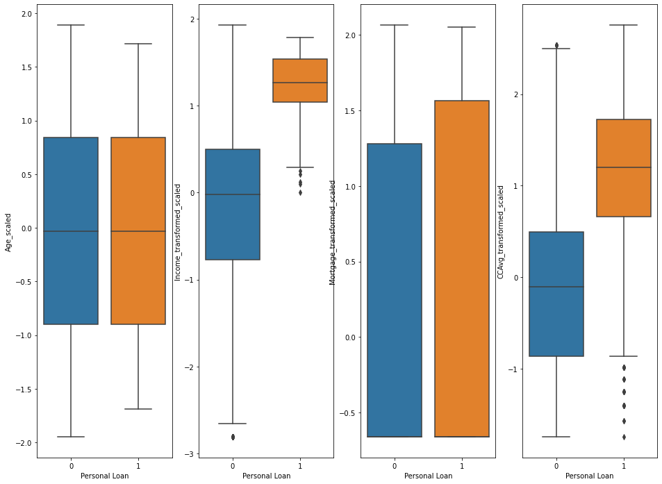

```python
# Boxplots to visualize the ouliers after the scaling
fig, axs = plt.subplots(ncols = len(features), figsize = (16, 12))

for idx, field in enumerate(features):
    sns.boxplot(x = 'Personal Loan',
                y = field,
                data = num_df2,
                ax = axs[idx])
```

### Replacing outliers using IQR values

```python
num_df2.drop('Personal Loan', axis=1, inplace=True)
num_df2.dtypes
```

```
Age_scaled                     float64
Income_transformed_scaled      float64
Mortgage_transformed_scaled    float64
CCAvg_transformed_scaled       float64
dtype: object
```

```python
Q1 = num_df2.quantile(q=0.25)
Q3 = num_df2.quantile(q=0.75)
IQR = Q3 - Q1
```

```python
outliers = np.where((num_df2 < (Q1 - 1.5 * IQR)) | (num_df2 > (Q3 + 1.5 * IQR)))
len(outliers[0])
```

```
52
```

```python
num_df3 = num_df2.copy()

# Replace every outlier on the lower side by the lower whisker
for i, j in zip(np.where(num_df3 < Q1 - 1.5 * IQR)[0], np.where(num_df3 < Q1 - 1.5 * IQR)[1]):

    whisker  = Q1 - 1.5 * IQR
    num_df3.iloc[i,j] = whisker[j]

#Replace every outlier on the upper side by the upper whisker
for i, j in zip(np.where(num_df3 > Q3 + 1.5 * IQR)[0], np.where(num_df3 > Q3 + 1.5 * IQR)[1]):

    whisker  = Q3 + 1.5 * IQR
    num_df3.iloc[i,j] = whisker[j]

num_df3.head()
```

|  | Age_scaled | Income_transformed_scaled | Mortgage_transformed_scaled | CCAvg_transformed_scaled |
| --- | --- | --- | --- | --- |
| 0 | -1.774417 | -0.286700 | -0.662238 | 0.049051 |
| 1 | -0.029524 | -0.811294 | -0.662238 | -0.024503 |
| 2 | -0.552992 | -2.385689 | -0.662238 | -0.442985 |
| 3 | -0.901970 | 0.747409 | -0.662238 | 0.710731 |
| 4 | -0.901970 | -0.409337 | -0.662238 | -0.442985 |

```python
num_df3.shape
```

```
(5000, 4)
```

```python
num_df3.drop('Personal Loan', axis=1, inplace=True)
Q1 = num_df3.quantile(q=0.25)
Q3 = num_df3.quantile(q=0.75)
IQR = Q3 - Q1
outliers = np.where((num_df3 < (Q1 - 1.5 * IQR)) | (num_df3 > (Q3 + 1.5 * IQR)))
len(outliers[0])
```

[output not shown]

# Parts 3-4

**Logistic Regression model construction**

- Splitting the data into training and test set in the ratio of 70:30 respectively
- Logistic Regression model to predict whether the customer will take a personal loan or not
- Print all the metrics related to evaluating the model performance (accuracy, recall, precision, f1score, and roc_auc_score)
- Heatmap to display confusion matrix

```python
df2=num_df3.copy()
```

```python
# Putting back the categorical columns
for i in list(df.columns[df.dtypes=='category']):   # checking value counts of all category type columns
    df2[i]=df[i]

df2.head()
```

|  | Age_scaled | Income_transformed_scaled | Mortgage_transformed_scaled | CCAvg_transformed_scaled | ZIP Code | Family | Education | Personal Loan | Securities Account | CD Account | Online | CreditCard |
| --- | --- | --- | --- | --- | --- | --- | --- | --- | --- | --- | --- | --- |
| 0 | -1.774417 | -0.286700 | -0.662238 | 0.049051 | 91107 | 4 | 1 | 0 | 1 | 0 | 0 | 0 |
| 1 | -0.029524 | -0.811294 | -0.662238 | -0.024503 | 90089 | 3 | 1 | 0 | 1 | 0 | 0 | 0 |
| 2 | -0.552992 | -2.385689 | -0.662238 | -0.442985 | 94720 | 1 | 1 | 0 | 0 | 0 | 0 | 0 |
| 3 | -0.901970 | 0.747409 | -0.662238 | 0.710731 | 94112 | 1 | 2 | 0 | 0 | 0 | 0 | 0 |
| 4 | -0.901970 | -0.409337 | -0.662238 | -0.442985 | 91330 | 4 | 2 | 0 | 0 | 0 | 0 | 1 |

```python
onehotcols=['Family', 'Education']
```

```python
# family_df=pd.get_dummies(df2['Family'], prefix='Family_')
# edu_df=pd.get_dummies(df2['Education'], prefix='Education_')
```

```python
df3=pd.get_dummies(df2, columns=onehotcols)
df3.head()
```

|  | Age_scaled | Income_transformed_scaled | Mortgage_transformed_scaled | CCAvg_transformed_scaled | ZIP Code | Personal Loan | Securities Account | CD Account | Online | CreditCard | Family_1 | Family_2 | Family_3 | Family_4 | Education_1 | Education_2 | Education_3 |
| --- | --- | --- | --- | --- | --- | --- | --- | --- | --- | --- | --- | --- | --- | --- | --- | --- | --- |
| 0 | -1.774417 | -0.286700 | -0.662238 | 0.049051 | 91107 | 0 | 1 | 0 | 0 | 0 | 0 | 0 | 0 | 1 | 1 | 0 | 0 |
| 1 | -0.029524 | -0.811294 | -0.662238 | -0.024503 | 90089 | 0 | 1 | 0 | 0 | 0 | 0 | 0 | 1 | 0 | 1 | 0 | 0 |
| 2 | -0.552992 | -2.385689 | -0.662238 | -0.442985 | 94720 | 0 | 0 | 0 | 0 | 0 | 1 | 0 | 0 | 0 | 1 | 0 | 0 |
| 3 | -0.901970 | 0.747409 | -0.662238 | 0.710731 | 94112 | 0 | 0 | 0 | 0 | 0 | 1 | 0 | 0 | 0 | 0 | 1 | 0 |
| 4 | -0.901970 | -0.409337 | -0.662238 | -0.442985 | 91330 | 0 | 0 | 0 | 0 | 1 | 0 | 0 | 0 | 1 | 0 | 1 | 0 |

```python
df3.dtypes
```

```
Age_scaled                      float64
Income_transformed_scaled       float64
Mortgage_transformed_scaled     float64
CCAvg_transformed_scaled        float64
ZIP Code                       category
Personal Loan                  category
Securities Account             category
CD Account                     category
Online                         category
CreditCard                     category
Family_1                          uint8
Family_2                          uint8
Family_3                          uint8
Family_4                          uint8
Education_1                       uint8
Education_2                       uint8
Education_3                       uint8
dtype: object
```

### Asigning X and y, and splitting the data

```python
## Define X and Y variables. ZIP Code is excluded
X = df3.drop(['Personal Loan', 'ZIP Code'], axis=1)
y = df3['Personal Loan']

print(X.shape, y.shape)
```

```
(5000, 15) (5000,)
```

```python
##Split into training and test set
X_train, X_test, y_train, y_test = train_test_split(X, y, stratify=y, test_size=0.30, random_state=11)
```

### Logistic Regression model

```python
# fit the model on train data
from sklearn.metrics import confusion_matrix, recall_score, precision_score, f1_score, roc_auc_score,accuracy_score

logreg = LogisticRegression(random_state=856759, fit_intercept=False, solver='liblinear', max_iter=1000)
logreg.fit(X_train, y_train)
```

```
LogisticRegression(C=1.0, class_weight=None, dual=False, fit_intercept=False,
                   intercept_scaling=1, l1_ratio=None, max_iter=1000,
                   multi_class='warn', n_jobs=None, penalty='l2',
                   random_state=856759, solver='liblinear', tol=0.0001,
                   verbose=0, warm_start=False)
```

```python
# Predict test data
y_predict = logreg.predict(X_test)
```

```python
# Observe the predicted and observed values in a dataframe, called "z".
z = X_test.copy()
z['Actual Loan'] = y_test
z['Predicted Loan'] = y_predict
z.head()
```

|  | Age_scaled | Income_transformed_scaled | Mortgage_transformed_scaled | CCAvg_transformed_scaled | Securities Account | CD Account | Online | CreditCard | Family_1 | Family_2 | Family_3 | Family_4 | Education_1 | Education_2 | Education_3 | Actual Loan | Predicted Loan |
| --- | --- | --- | --- | --- | --- | --- | --- | --- | --- | --- | --- | --- | --- | --- | --- | --- | --- |
| 1168 | 1.453636 | -0.652134 | -0.662238 | -0.351485 | 0 | 0 | 1 | 0 | 1 | 0 | 0 | 0 | 0 | 0 | 1 | 0 | 0 |
| 1404 | 1.104657 | 0.329135 | -0.662238 | -0.101060 | 0 | 0 | 1 | 0 | 1 | 0 | 0 | 0 | 0 | 0 | 1 | 0 | 0 |
| 3852 | -1.076460 | -1.962569 | 1.205253 | -1.111892 | 1 | 1 | 1 | 1 | 1 | 0 | 0 | 0 | 0 | 1 | 0 | 0 | 0 |
| 1495 | 0.581189 | 1.589092 | 1.449684 | 1.738383 | 0 | 0 | 1 | 0 | 0 | 0 | 1 | 0 | 0 | 0 | 1 | 1 | 1 |
| 4455 | 0.930168 | -1.087879 | -0.662238 | -0.024503 | 1 | 1 | 1 | 1 | 1 | 0 | 0 | 0 | 0 | 1 | 0 | 0 | 0 |

### Model performance evaluation (accuracy, recall, precision, f1score, and roc_auc_score) with Heatmap to display confusion matrix

```python
## function to get confusion matrix in a proper format
def draw_cm( actual, predicted ):
    cm = confusion_matrix( actual, predicted)
    sns.heatmap(cm, annot=True,  fmt='.2f', xticklabels = [0,1] , yticklabels = [0,1] )
    plt.ylabel('Observed')
    plt.xlabel('Predicted')
    plt.show()
```

```
Trainig accuracy 0.9662857142857143

Testing accuracy 0.962

Confusion Matrix
```

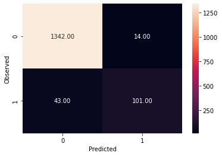

```
None

Recall: 0.7013888888888888

Precision: 0.8782608695652174

F1 Score: 0.7799227799227799

Roc Auc Score: 0.8455322025565388
```

```python
print("Trainig accuracy",logreg.score(X_train,y_train))
print()
print("Testing accuracy",logreg.score(X_test, y_test))
print()
print('Confusion Matrix')
print(draw_cm(y_test,y_predict))
print()
print("Recall:",recall_score(y_test,y_predict))
print()
print("Precision:",precision_score(y_test,y_predict))
print()
print("F1 Score:",f1_score(y_test,y_predict))
print()
print("Roc Auc Score:",roc_auc_score(y_test,y_predict))
```

# Part 5

**Logistic Regression model outcome**

- Showing coefficients impacts of all the attributes
- For test data showing all the rows where the predicted class is not equal to the observed class.

#### Coefficients impacts of all the attributes

```python
## Feature Importance or Coefficients
fi = pd.DataFrame()
fi['Col'] = X_train.columns
fi['Coeff'] = np.round(logreg.coef_[0],2)
fi.sort_values(by='Coeff',ascending=False)
```

|  | Col | Coeff |
| --- | --- | --- |
| 1 | Income_transformed_scaled | 4.29 |
| 5 | CD Account | 3.01 |
| 3 | CCAvg_transformed_scaled | 0.53 |
| 2 | Mortgage_transformed_scaled | 0.11 |
| 0 | Age_scaled | 0.09 |
| 6 | Online | -0.74 |
| 4 | Securities Account | -0.78 |
| 7 | CreditCard | -0.93 |
| 10 | Family_3 | -1.15 |
| 11 | Family_4 | -1.67 |
| 14 | Education_3 | -1.78 |
| 13 | Education_2 | -1.82 |
| 8 | Family_1 | -2.98 |
| 9 | Family_2 | -3.07 |
| 12 | Education_1 | -5.27 |

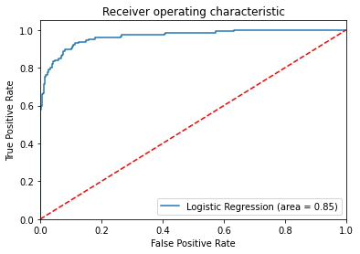

```python
#AUC ROC curve
from sklearn.metrics import roc_auc_score
from sklearn.metrics import roc_curve

logit_roc_auc = roc_auc_score(y_test, logreg.predict(X_test))
fpr, tpr, thresholds = roc_curve(y_test, logreg.predict_proba(X_test)[:,1])
plt.figure()
plt.plot(fpr, tpr, label='Logistic Regression (area = %0.2f)' % logit_roc_auc)
plt.plot([0, 1], [0, 1],'r--')
plt.xlim([0.0, 1.0])
plt.ylim([0.0, 1.05])
plt.xlabel('False Positive Rate')
plt.ylabel('True Positive Rate')
plt.title('Receiver operating characteristic')
plt.legend(loc="lower right")
plt.savefig('Log_ROC')
plt.show()
```

#### For test data all the rows where the predicted class is not equal to the observed class.

```python
# Predicted and observed values dataframe.
z.head()
```

|  | Age_scaled | Income_transformed_scaled | Mortgage_transformed_scaled | CCAvg_transformed_scaled | Securities Account | CD Account | Online | CreditCard | Family_1 | Family_2 | Family_3 | Family_4 | Education_1 | Education_2 | Education_3 | Actual Loan | Predicted Loan |
| --- | --- | --- | --- | --- | --- | --- | --- | --- | --- | --- | --- | --- | --- | --- | --- | --- | --- |
| 1168 | 1.453636 | -0.652134 | -0.662238 | -0.351485 | 0 | 0 | 1 | 0 | 1 | 0 | 0 | 0 | 0 | 0 | 1 | 0 | 0 |
| 1404 | 1.104657 | 0.329135 | -0.662238 | -0.101060 | 0 | 0 | 1 | 0 | 1 | 0 | 0 | 0 | 0 | 0 | 1 | 0 | 0 |
| 3852 | -1.076460 | -1.962569 | 1.205253 | -1.111892 | 1 | 1 | 1 | 1 | 1 | 0 | 0 | 0 | 0 | 1 | 0 | 0 | 0 |
| 1495 | 0.581189 | 1.589092 | 1.449684 | 1.738383 | 0 | 0 | 1 | 0 | 0 | 0 | 1 | 0 | 0 | 0 | 1 | 1 | 1 |
| 4455 | 0.930168 | -1.087879 | -0.662238 | -0.024503 | 1 | 1 | 1 | 1 | 1 | 0 | 0 | 0 | 0 | 1 | 0 | 0 | 0 |

```python
len(z)
```

```
1500
```

```python
deviation_df=z.loc[(z['Actual Loan'])!=(z['Predicted Loan'])]
#deviation_df
```

```python
len(deviation_df)
```

```
57
```

```python
#Testing loss, %

len(deviation_df)/len(z)*100
```

```
3.8
```

```python
missed_group=z.loc[(z['Actual Loan']!=z['Predicted Loan']) & (z['Actual Loan']==1)]
missed_group.head()
```

|  | Age_scaled | Income_transformed_scaled | Mortgage_transformed_scaled | CCAvg_transformed_scaled | Securities Account | CD Account | Online | CreditCard | Family_1 | Family_2 | Family_3 | Family_4 | Education_1 | Education_2 | Education_3 | Actual Loan | Predicted Loan |
| --- | --- | --- | --- | --- | --- | --- | --- | --- | --- | --- | --- | --- | --- | --- | --- | --- | --- |
| 4575 | 0.668434 | 0.951069 | -0.662238 | -0.982503 | 0 | 0 | 0 | 0 | 0 | 1 | 0 | 0 | 0 | 0 | 1 | 1 | 0 |
| 1577 | -0.989215 | 0.121638 | 1.632313 | 0.856940 | 0 | 0 | 1 | 0 | 1 | 0 | 0 | 0 | 1 | 0 | 0 | 1 | 0 |
| 4124 | 0.668434 | 1.248517 | -0.662238 | -1.400986 | 0 | 0 | 0 | 0 | 0 | 1 | 0 | 0 | 0 | 0 | 1 | 1 | 0 |
| 2002 | -1.338194 | 1.258839 | 1.825348 | 1.348977 | 0 | 0 | 0 | 0 | 0 | 0 | 1 | 0 | 1 | 0 | 0 | 1 | 0 |
| 1069 | -0.116768 | 0.329135 | -0.662238 | 1.077830 | 0 | 0 | 1 | 0 | 0 | 1 | 0 | 0 | 1 | 0 | 0 | 1 | 0 |

```python
len(missed_group)
```

```
43
```

```python
missed_data=missed_group[['Age_scaled', 'Income_transformed_scaled', 'Mortgage_transformed_scaled', 'CCAvg_transformed_scaled']]
```

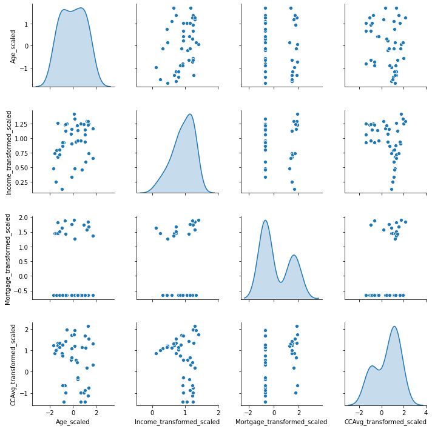

```python
sns.pairplot(missed_data, diag_kind='kde')
plt.show()
```

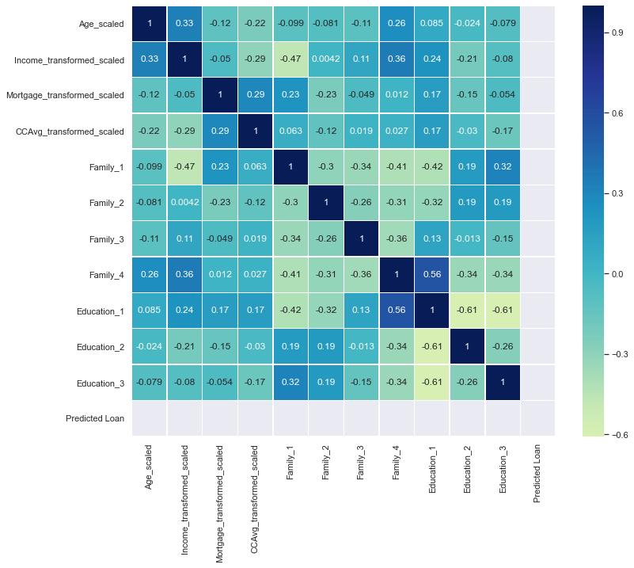

```python
sns.set(rc={'figure.figsize':(12,10)})
sns.heatmap(missed_group.corr(),
            annot=True,
            linewidths=.5,
            center=0,
#            cbar=False,
            cmap="YlGnBu")
plt.show()
```

**Insights:**

- `57 is number equal to sum of False Poistive (14) and False Negative (43)`

## Business Insights

##### `Confusion matrix means`

*True Positive (observed=1,predicted=1):*

Predicted 101 customers (from 1500 applicants) that will be taking a loan.

*False Positive (observed=0,predicted=1):*

Predicted that these customers will be taking a loan, but they did not take a loan (14 customers)

*True Negative (observed=0,predicted=0):*

Predicted that 1342 customers will not be taking a loan, and they did not take a loan

*False Negative (observed=1,predicted=0):*

Predicted that customers will not be taking a loan, but they did take a loan (43 customers) (They were separated, and can be further analyzed).

##### `Important Features`

Top 5 features which were found to impact the model output, based on the highest coefficients values (from the highest to lower impact):

"Income", "CD Account", "CCAvg" (monthly avergae credit card spendings), "Mortgage", and "Age"

##### `Important Metric`

Here the bank wants to suggest a loan to customers and benefit from the loan sale, i.e. **less number of False Negative**, if FN is high, bank would loss money by not suggesting them to apply for a loan. Hence **Recall score (Sensitivity)** is the important metric, if FN is high, bank would loss money wihtout potential loan customers.

In case of False positive bank will lose some money on advertisement which will not reach the target. The **F1 score** (the weighted average of the Precision and the recall scores) can be second important metric in this case.

The model can be deployed for practical use, as Thera Bank can target loan customers and predict who will be interested in taking a loan. They can use the model for upcoming customers.